# PLM - Prediction Assignment Writeup

S Nenning

7 October 2018

# 1. Synopsis

The objective of this project is to create a prediction model on the manner how **Unilateral Dumbbell Biceps Curl** exercise is performed using training data collected from accelerometers on the belt, forearm, arm, and dumbell of 6 participants performing the exercise. The participants were asked to perform the exercise correctly and incorrectly in 5 different ways and its execution was then classified by an experienced weight lifter into class A to class E.

The machine learning algorithm (prediction) model is tested on the 20 test cases available in the test data provided for this project.

The data for this project come from this source: http://groupware.les.inf.puc-rio.br/har.

#### Summary

3 machine learning algorithm methods have been validated. **Random Forest** with an accuracy of **0.95** has been selected for predicting the outcome for the 20 test cases, which is:

[1] B A C A A E D B A A B C B A E E A B B B

# 2. Data Analysis

### Loading and preprocessing the data

As the first step, data files are downloaded from website, when not downlaoded previously to R working directory, and read it into R.

```r
# download files only  if not yet existing in working directory
if (!file.exists("pml-training.csv")) {
  fileUrl <- "https://d396qusza40orc.cloudfront.net/predmachlearn/pml-training.csv"
  download.file(fileUrl, destfile = "pml-training.csv", method = "curl")
}
pml_training <- read.csv(file = "pml-training.csv", header = TRUE, na.strings = "NA")
if (!file.exists("pml-testing.csv")) {
  fileUrl <- "https://d396qusza40orc.cloudfront.net/predmachlearn/pml-testing.csv"
  download.file(fileUrl, destfile = "pml-testing.csv", method = "curl")
}
pml_testing <-  read.csv(file = "pml-testing.csv", header = TRUE, na.strings = "NA")
```

A brief exploratory data analysis is done to understand the data content and number of available records. The training data (*pml_training*) contains 160 columns with 19622 records. I subset the data into the outcome variable *classe* and predictors, which is the accelerometers data of the sensors on the participants’ belt, forearm, arm, and dumbell. Subset for predictors is created from the variable name beginning with ‘*accel*’.

```r
# basic data exploratory and subsetting data
training_pos_accel <-  grep("^accel", names(pml_training))
pml_training <- cbind("classe" = pml_training$classe, pml_training[,training_pos_accel])

str(pml_training)
```

```
## 'data.frame':    19622 obs. of  13 variables:
##  $ classe          : Factor w/ 5 levels "A","B","C","D",..: 1 1 1 1 1 1 1 1 1 1 ...
##  $ accel_belt_x    : int  -21 -22 -20 -22 -21 -21 -22 -22 -20 -21 ...
##  $ accel_belt_y    : int  4 4 5 3 2 4 3 4 2 4 ...
##  $ accel_belt_z    : int  22 22 23 21 24 21 21 21 24 22 ...
##  $ accel_arm_x     : int  -288 -290 -289 -289 -289 -289 -289 -289 -288 -288 ...
##  $ accel_arm_y     : int  109 110 110 111 111 111 111 111 109 110 ...
##  $ accel_arm_z     : int  -123 -125 -126 -123 -123 -122 -125 -124 -122 -124 ...
##  $ accel_dumbbell_x: int  -234 -233 -232 -232 -233 -234 -232 -234 -232 -235 ...
##  $ accel_dumbbell_y: int  47 47 46 48 48 48 47 46 47 48 ...
##  $ accel_dumbbell_z: int  -271 -269 -270 -269 -270 -269 -270 -272 -269 -270 ...
##  $ accel_forearm_x : int  192 192 196 189 189 193 195 193 193 190 ...
##  $ accel_forearm_y : int  203 203 204 206 206 203 205 205 204 205 ...
##  $ accel_forearm_z : int  -215 -216 -213 -214 -214 -215 -215 -213 -214 -215 ...
```

Please see above the structure of the subset created with outcome and predictor variables. There are 12 predictors; x,y,z variables for each sensor. Outcome variable *classe* is a factor calling for a **classification machine learning algorthm** model. Multiple models are looked at, next.

### Machine Learning Algorithm models

#### Preparing data

The training data is split into ‘training’ and ‘validation’ data using a split ratio of 0.7. The training data is used to ‘train’ the models; the ‘validation’ data for validating the model afterwards. The downloaded test data is subsetted on the same predictor variables as the training data. Data ‘testing’ is used to the predict the classification for the 20 test cases included in the test data.

```r
# setting seed to get same sample set when creating data partition.
set.seed(12321)
intrain <- createDataPartition(pml_training$classe, p=0.7, list = FALSE)

training <- pml_training[intrain,]
validation <-  pml_training[-intrain,]

# Downloaded test data is subsetted on the same predictor variables as the training data.
testing <-  pml_testing[,training_pos_accel]
```

The ‘training’ data contains 13737 records, ‘validation’ data 5885 records, and ‘testing’ 20 records.

#### Fitting the model

I have chosen to use 3 different classification machine learning algorthm for fitting the model. The ‘Final Model’ values are printing for each model.

##### a.) Fitting Model using **Decision tree** algorithm

The logic of decision tree is to partition the data considering a set of questions (nodes), using as first method **rpart** in *train* funcion from package *caret*.

```r
# fit a model with tree
modfit_rpart <- train(classe ~., data = training, method = "rpart")
print(modfit_rpart$finalModel)
```

```
## n= 13737
##
## node), split, n, loss, yval, (yprob)
##       * denotes terminal node
##
##  1) root 13737 9831 A (0.28 0.19 0.17 0.16 0.18)
##    2) accel_belt_z>=-187.5 13016 9114 A (0.3 0.2 0.18 0.17 0.14)
##      4) accel_arm_x< -271.5 2134  774 A (0.64 0.11 0.13 0.047 0.069) *
##      5) accel_arm_x>=-271.5 10882 8340 A (0.23 0.22 0.19 0.2 0.15)
##       10) accel_dumbbell_x< 38.5 10010 7504 A (0.25 0.2 0.21 0.21 0.13)
##         20) accel_forearm_x>=-99.5 5790 4071 A (0.3 0.23 0.24 0.1 0.13) *
##         21) accel_forearm_x< -99.5 4220 2696 D (0.19 0.15 0.17 0.36 0.13) *
##       11) accel_dumbbell_x>=38.5 872  426 B (0.041 0.51 0.018 0.047 0.38) *
##    3) accel_belt_z< -187.5 721    5 E (0.0055 0.0014 0 0 0.99) *
```

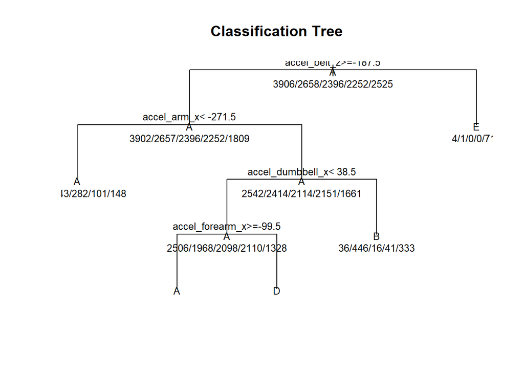

```r
plot(modfit_rpart$finalModel, uniform = TRUE, main = "Classification Tree")
text(modfit_rpart$finalModel, use.n = TRUE, all = TRUE, cex=.8)
```

Fig1: Classification Tree showing nodes and branches of the classification

##### b.) Fitting Model using **Random Forest** algorithm

Random forests creates decision trees on randomly selected data samples, gets prediction from each tree and selects the best solution. I’m using method **rf** in *train* funcion from package *caret*

```r
# fit a model with random forest
modfit_rf <- train(classe ~., data = training, method = "rf")
print(modfit_rf$finalModel)
```

```
##
## Call:
##  randomForest(x = x, y = y, mtry = param$mtry)
##                Type of random forest: classification
##                      Number of trees: 500
## No. of variables tried at each split: 2
##
##         OOB estimate of  error rate: 5.57%
## Confusion matrix:
##      A    B    C    D    E class.error
## A 3773   26   42   59    6  0.03405018
## B  114 2413   86   29   16  0.09217457
## C   40   63 2267   24    2  0.05383973
## D   56   11   99 2075   11  0.07859680
## E    4   34   21   22 2444  0.03207921
```

##### c.) Fitting Model using **Gradient boosting modelling**

Boosting is another approach to improve the predictions resulting from a decision tree. Trees are ‘grown’ sequentially: each tree is grown using information from previously grown trees. I’m using method **gbm** in *train* funcion from package *caret*.

```r
# fit a model with boosting
modfit_gbm <- train(classe ~., data = training, method = "gbm", verbose = FALSE)
print(modfit_gbm$finalModel)
```

```
## A gradient boosted model with multinomial loss function.
## 150 iterations were performed.
## There were 12 predictors of which 12 had non-zero influence.
```

#### Model validation

The Machine Learning Algorithm models are validated against the ‘validation’ data.  
Steps taken for each model is to:  
- Predict the outcome value (variable *classe*) with the model using the validation data.  
- Plot the predicted values (see histograms Fig2 to Fig4 below)  
- Present a table showing actual outcome values from the validation data versus the predicted outcome values using the model.  
- Compute and print confusion matrix to get model parameters like accuracy of prediction model.

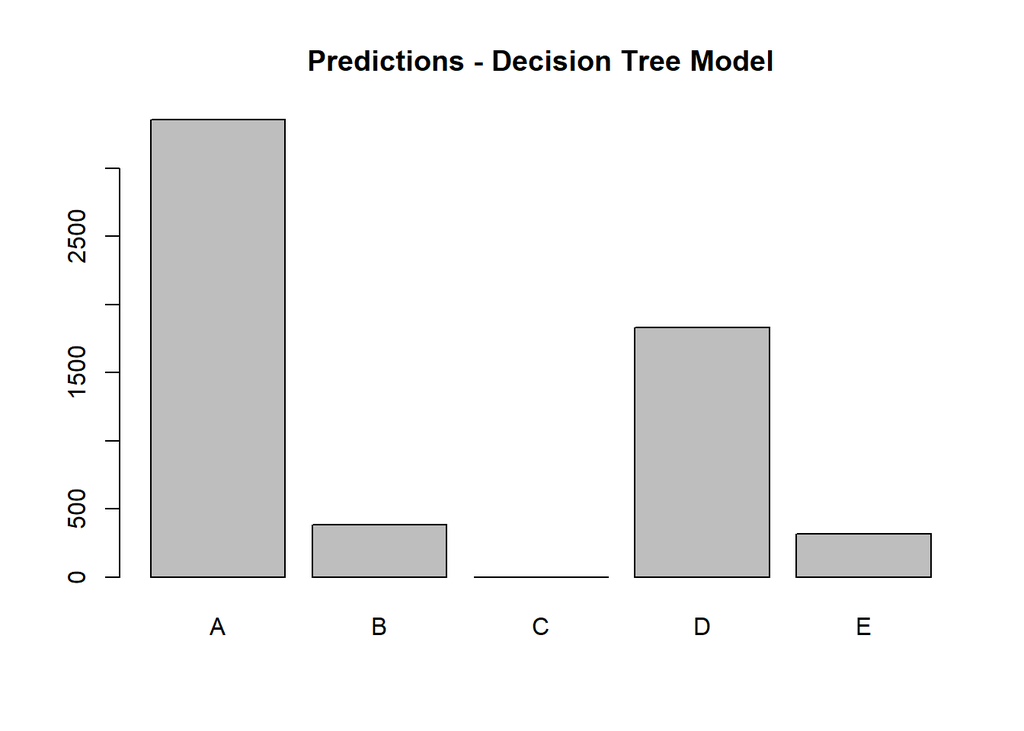

```r
# Prediction with tree model
pred_rpart <- predict(modfit_rpart, newdata  = validation)
plot(pred_rpart, main = "Predictions - Decision Tree Model")
```

```r
table(validation$classe, pred_rpart)
```

```
##    pred_rpart
##        A    B    C    D    E
##   A 1308   14    0  350    2
##   B  653  198    0  288    0
##   C  719   14    0  293    0
##   D  298   17    0  649    0
##   E  379  142    0  249  312
```

```r
cfm_rpart <- confusionMatrix(validation$classe, pred_rpart)
print(cfm_rpart)
```

```
## Confusion Matrix and Statistics
##
##           Reference
## Prediction    A    B    C    D    E
##          A 1308   14    0  350    2
##          B  653  198    0  288    0
##          C  719   14    0  293    0
##          D  298   17    0  649    0
##          E  379  142    0  249  312
##
## Overall Statistics
##
##                Accuracy : 0.4192
##                  95% CI : (0.4066, 0.4319)
##     No Information Rate : 0.5704
##     P-Value [Acc > NIR] : 1
##
##                   Kappa : 0.2401
##  Mcnemar's Test P-Value : NA
##
## Statistics by Class:
##
##                      Class: A Class: B Class: C Class: D Class: E
## Sensitivity            0.3896  0.51429       NA   0.3548  0.99363
## Specificity            0.8552  0.82891   0.8257   0.9223  0.86178
## Pos Pred Value         0.7814  0.17384       NA   0.6732  0.28835
## Neg Pred Value         0.5134  0.96060       NA   0.7602  0.99958
## Prevalence             0.5704  0.06542   0.0000   0.3108  0.05336
## Detection Rate         0.2223  0.03364   0.0000   0.1103  0.05302
## Detection Prevalence   0.2845  0.19354   0.1743   0.1638  0.18386
## Balanced Accuracy      0.6224  0.67160       NA   0.6386  0.92771
```

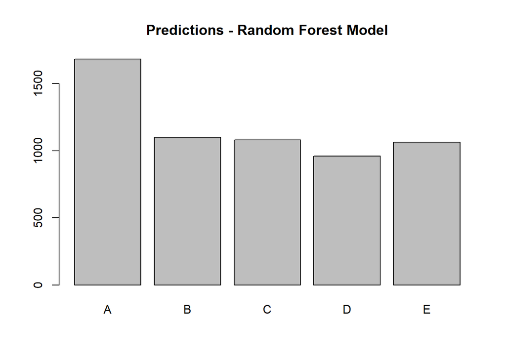

```r
# Prediction with random forest model
pred_rf <- predict(modfit_rf, newdata  = validation)
plot(pred_rf, main = "Predictions - Random Forest Model")
```

```r
table(validation$classe, pred_rf)
```

```
##    pred_rf
##        A    B    C    D    E
##   A 1617    6   26   24    1
##   B   37 1050   38    8    6
##   C   11   30  976    7    2
##   D   16    1   27  914    6
##   E    1   13   13    7 1048
```

```r
cfm_rf <- confusionMatrix(validation$classe, pred_rf)
print(cfm_rf)
```

```
## Confusion Matrix and Statistics
##
##           Reference
## Prediction    A    B    C    D    E
##          A 1617    6   26   24    1
##          B   37 1050   38    8    6
##          C   11   30  976    7    2
##          D   16    1   27  914    6
##          E    1   13   13    7 1048
##
## Overall Statistics
##
##                Accuracy : 0.9524
##                  95% CI : (0.9467, 0.9577)
##     No Information Rate : 0.2858
##     P-Value [Acc > NIR] : < 2.2e-16
##
##                   Kappa : 0.9398
##  Mcnemar's Test P-Value : 5.842e-09
##
## Statistics by Class:
##
##                      Class: A Class: B Class: C Class: D Class: E
## Sensitivity            0.9614   0.9545   0.9037   0.9521   0.9859
## Specificity            0.9864   0.9814   0.9896   0.9898   0.9929
## Pos Pred Value         0.9659   0.9219   0.9513   0.9481   0.9686
## Neg Pred Value         0.9846   0.9895   0.9786   0.9907   0.9969
## Prevalence             0.2858   0.1869   0.1835   0.1631   0.1806
## Detection Rate         0.2748   0.1784   0.1658   0.1553   0.1781
## Detection Prevalence   0.2845   0.1935   0.1743   0.1638   0.1839
## Balanced Accuracy      0.9739   0.9680   0.9466   0.9710   0.9894
```

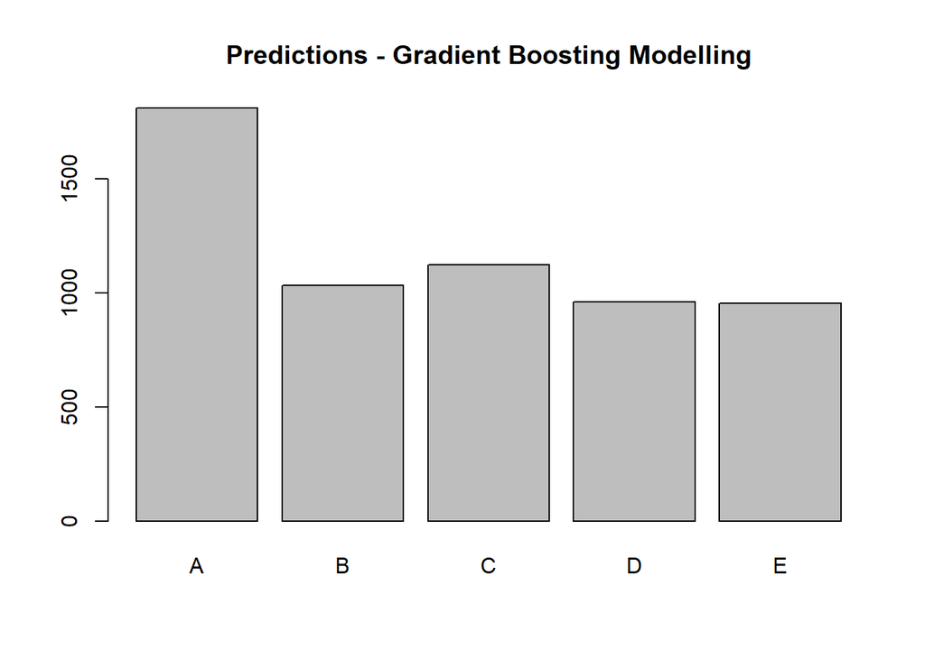

```r
# Prediction with boosting model
pred_gbm <- predict(modfit_gbm, newdata  = validation)
plot(pred_gbm, main = "Predictions - Gradient Boosting Modelling")
```

```r
table(validation$classe, pred_gbm)
```

```
##    pred_gbm
##        A    B    C    D    E
##   A 1491   34   63   85    1
##   B  126  828  110   37   38
##   C   88   70  828   32    8
##   D   84   28   66  767   19
##   E   23   75   56   40  888
```

```r
cfm_gbm <- confusionMatrix(validation$classe, pred_gbm)
print(cfm_gbm)
```

```
## Confusion Matrix and Statistics
##
##           Reference
## Prediction    A    B    C    D    E
##          A 1491   34   63   85    1
##          B  126  828  110   37   38
##          C   88   70  828   32    8
##          D   84   28   66  767   19
##          E   23   75   56   40  888
##
## Overall Statistics
##
##                Accuracy : 0.816
##                  95% CI : (0.8058, 0.8258)
##     No Information Rate : 0.3079
##     P-Value [Acc > NIR] : < 2.2e-16
##
##                   Kappa : 0.7666
##  Mcnemar's Test P-Value : < 2.2e-16
##
## Statistics by Class:
##
##                      Class: A Class: B Class: C Class: D Class: E
## Sensitivity            0.8228   0.8000   0.7373   0.7981   0.9308
## Specificity            0.9551   0.9359   0.9584   0.9600   0.9607
## Pos Pred Value         0.8907   0.7270   0.8070   0.7956   0.8207
## Neg Pred Value         0.9238   0.9564   0.9393   0.9606   0.9863
## Prevalence             0.3079   0.1759   0.1908   0.1633   0.1621
## Detection Rate         0.2534   0.1407   0.1407   0.1303   0.1509
## Detection Prevalence   0.2845   0.1935   0.1743   0.1638   0.1839
## Balanced Accuracy      0.8890   0.8679   0.8479   0.8791   0.9457
```

The 3 models have following **accuracy**; values are retrieved from confusion matrix of model:  
- Decision Tree: 0.4192014  
- Random Forest: 0.9524214  
- Gradient Boosting: 0.8159728

## Results

Based on the accuracy of the models, I select the model using the **Random Forest** Machine Learning Algorithm with an accuracy of 0.9524214 against the validation data.

The predicted outcome for the 20 test cases from the testing data is printed below.

```r
# Prediction with random forest model
pred_rf_test <- predict(modfit_rf, newdata  = testing)
pred_rf_test
```

```
##  [1] B A C A A E D B A A B C B A E E A B B B
## Levels: A B C D E
```